# cv_alt

Karol Buda

2/15/2022

## Simulation and Data Preparation

Let’s assume we have two long-lived substates (whether its dimer vs monomer, conformers, etc)

We can simulate two enzymes with different mean activities, sample them unequally to result in different height peaks, and give them some intrinsic CV

```r
state_1 = 50
state_2 = 100

activity = c()

activity = c(activity, rnorm(1000, state_1, sd = 0.2*state_1))
activity = c(activity, rnorm(3000, state_2, sd = 0.2*state_2))

head(activity, 5)
```

```
## [1] 44.39524 47.69823 65.58708 50.70508 51.29288
```

Now we can view this as a density histogram

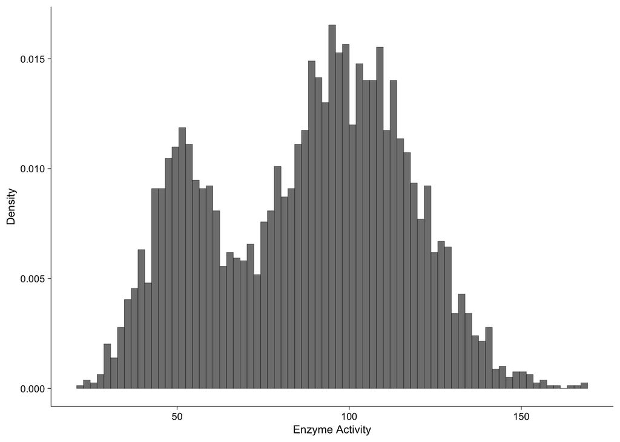

```r
p1 = as_tibble(activity) %>%
  ggplot(aes(x = value)) +
  geom_histogram(aes(y = ..density..), bins = 75, alpha = 0.8, color = "black", size = 0.1) +
  labs(x = "Enzyme Activity",
       y = "Density") +
  theme_classic() +
    theme(axis.line = element_line(size = 0.2, color = "black"), axis.ticks = element_line(size = 0.2, color = "black"), text = element_text(size = 9), axis.text = element_text(size = 8, color = "black"))

p1
```

## Initial Fitting

First its easier to create a data frame (tibble) where we use the histogram bins and densities from the previous plot

```r
activity_density = tibble(activity = ggplot_build(p1)$data[[1]]$x, density = ggplot_build(p1)$data[[1]]$y)
```

To make sure we “fit” both the single and double Gaussian, we will use a non-linear least squares fit for both. Starting with the definition of the single Gaussian function.

```r
single_gauss = function(x, C, mean, sigma) {
  return(C * exp(-(x-mean)**2/(2 * sigma**2)))
}
```

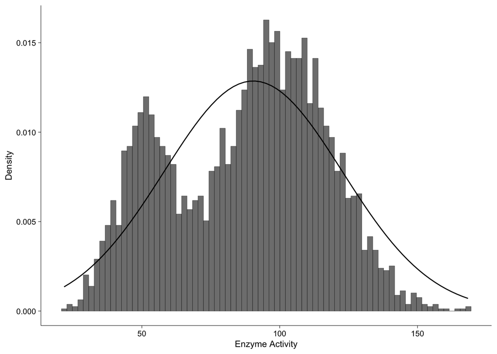

```r
fit_single <- nlsLM(density ~ single_gauss(activity, C, mean, sigma), data = activity_density, start=list(C=0.1, mean=150, sigma=0.2*150), lower = c(0, 0, 0))

single_gauss_params = as.list(summary(fit_single)$param[,1])

single_gauss_preds = do.call(single_gauss, c(list(x = activity_density$activity), single_gauss_params))

activity_density$single_gauss_preds = single_gauss_preds

p1 + geom_line(data = activity_density, aes(x = activity, y = single_gauss_preds))
```

What about a double Gaussian?

We define our double gauss function with C1 + C2 representing heights (i.e. densities), mean1 + mean 2 are the two means, and sigma1 + sigma2 are the standard deviations

```r
double_gauss = function(x, C1, mean1, sigma1, C2, mean2, sigma2) {
  return (C1 * exp(-(x-mean1)**2/(2 * sigma1**2)) + C2 * exp(-(x-mean2)**2/(2 * sigma2**2)))
}
```

Then we fit this using non-linear least squares, extract the parameters, and create a fit using the double Gaussian prediction

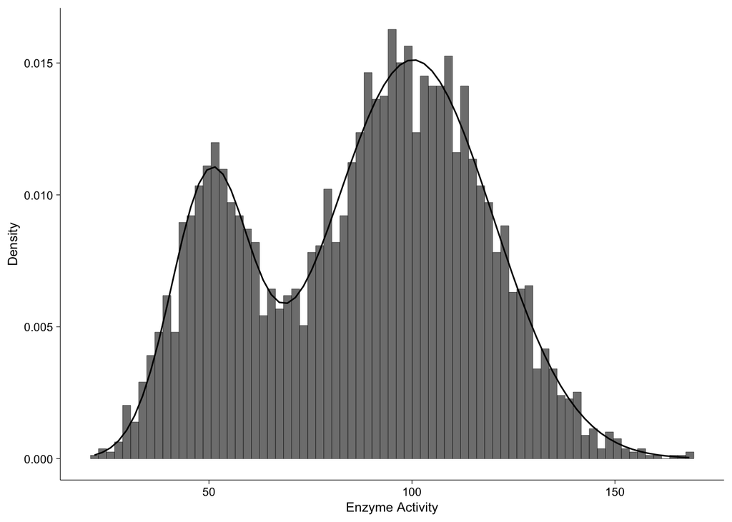

```r
fit_double <- nlsLM(density ~ double_gauss(activity, C1, mean1, sigma1, C2, mean2, sigma2), data = activity_density, start=list(C1=0.1, mean1=50, sigma1=0.2*50, C2=0.1, mean2=100, sigma2=0.2*100))

double_gauss_params = as.list(summary(fit_double)$param[,1])

double_gauss_preds = do.call(double_gauss, c(list(x = activity_density$activity), double_gauss_params))

activity_density$double_gauss_preds = double_gauss_preds

p1 + geom_line(data = activity_density, aes(x = activity, y = double_gauss_preds))
```

Much better fit, comparing the single gauss mean of 90.39 vs the two gauss means 50.29 and 100.24

The standard deviations of the two also differ, 32.33 for single versus 9.6 and 19.73

### Choosing single vs double Gaussian

Determining whether single or double gaussian is better should be done systematically through something like an AIC

```r
AIC(fit_single, fit_double)
```

```
##            df       AIC
## fit_single  4 -671.8321
## fit_double  7 -832.1595
```

Lower AIC is better, and here it’s no question that the double gaussian is better.

But what about “fuzzier” conditions?

## More Homogenous Data

Simulate same thing but with closer starting states, and more representation of the lower activity state, with the same 20% CV

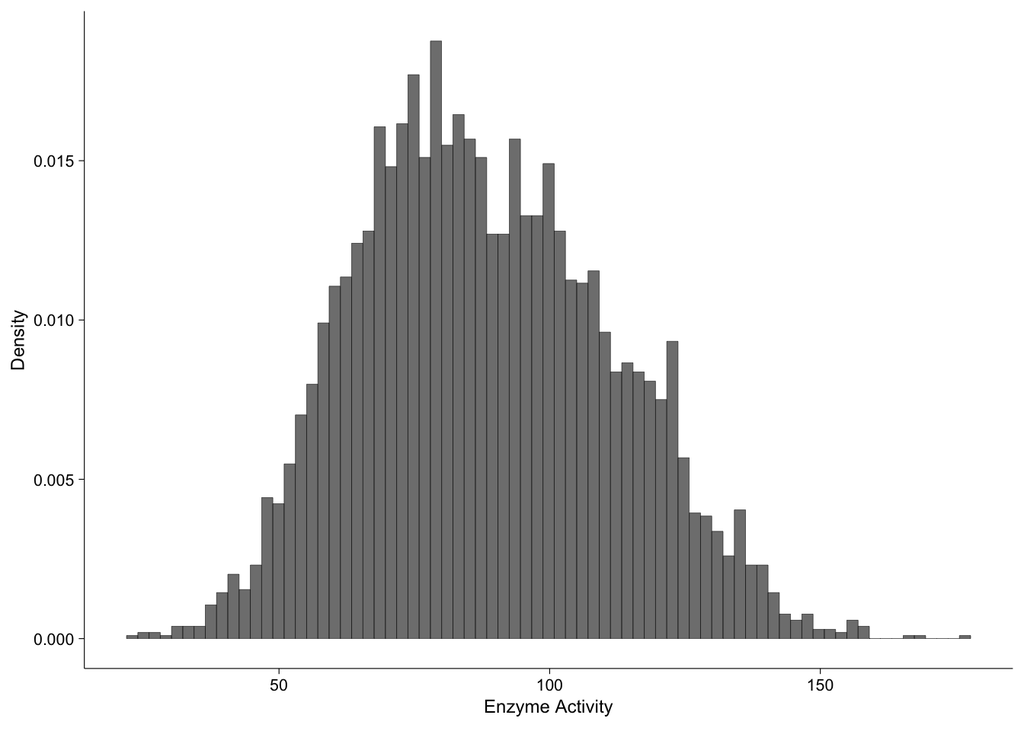

```r
state_1 = 70
state_2 = 100

activity_new = c()

activity_new = c(activity_new, rnorm(2000, state_1, sd = 0.2*state_1))
activity_new = c(activity_new, rnorm(3000, state_2, sd = 0.2*state_2))

p2 = as_tibble(activity_new) %>%
  ggplot(aes(x = value)) +
  geom_histogram(aes(y = ..density..), bins = 75, alpha = 0.8, color = "black", size = 0.1) +
  labs(x = expression("Enzyme Activity"),
       y = "Density") +
  theme_classic() +
    theme(axis.line = element_line(size = 0.2, color = "black"), axis.ticks = element_line(size = 0.2, color = "black"), text = element_text(size = 9), axis.text = element_text(size = 8, color = "black"))

p2
```

Make tibble and single fit using this data

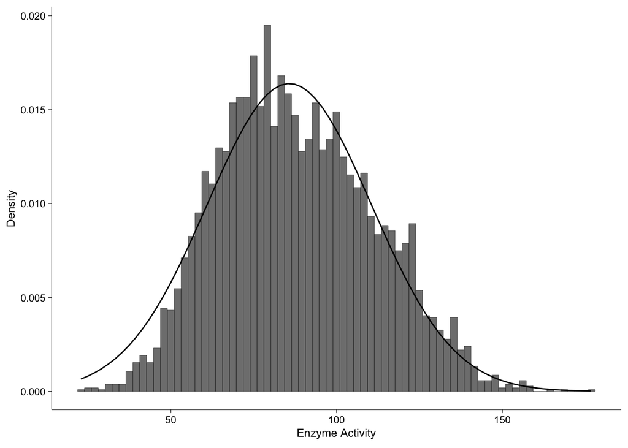

```r
activity_density_new = tibble(activity = ggplot_build(p2)$data[[1]]$x, density = ggplot_build(p2)$data[[1]]$y)

fit_single_new <- nlsLM(density ~ single_gauss(activity, C, mean, sigma), data = activity_density_new, start=list(C=0.01, mean=100, sigma=0.2*100))

single_gauss_params_new = as.list(summary(fit_single_new)$param[,1])

single_gauss_preds_new = do.call(single_gauss, c(list(x = activity_density_new$activity), single_gauss_params_new))

activity_density_new$single_gauss_preds_new = single_gauss_preds_new

p2 + geom_line(data = activity_density_new, aes(x = activity, y = single_gauss_preds_new))
```

Then again with the double fit

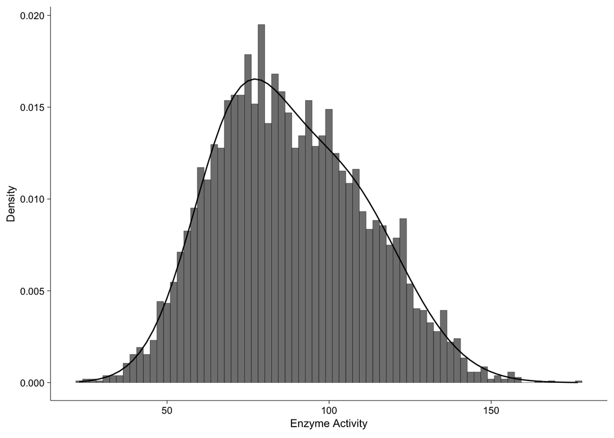

```r
fit_double_new <- nlsLM(density ~ double_gauss(activity, C1, mean1, sigma1, C2, mean2, sigma2), data = activity_density_new, start=list(C1=0.01, mean1=70, sigma1=0.2*70, C2=0.01, mean2=100, sigma2=0.2*100))

double_gauss_params_new = as.list(summary(fit_double_new)$param[,1])

double_gauss_preds_new = do.call(double_gauss, c(list(x = activity_density_new$activity), double_gauss_params_new))

activity_density$double_gauss_preds_new = double_gauss_preds_new

p2 + geom_line(data = activity_density_new, aes(x = activity, y = double_gauss_preds_new))
```

Fits are not as good… Let’s look at the AIC

```r
AIC(fit_single_new, fit_double_new)
```

```
##                df      AIC
## fit_single_new  4 -776.928
## fit_double_new  7 -841.724
```

Double is still better, but seems like it might always be better. What if we have noisy single state data?

## Single state data

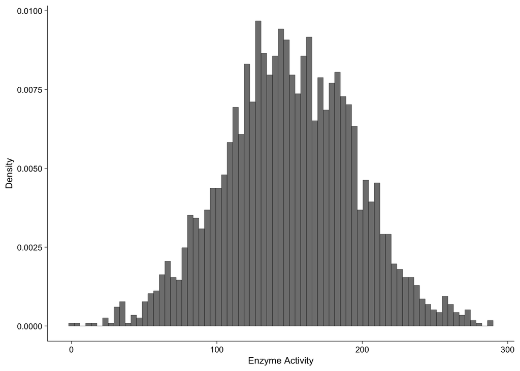

```r
state_1 = 150

activity_newer = c()
activity_newer = c(activity_newer, rnorm(3000, state_1, sd = 0.3*state_1))

# Had to add this as large SD lead to negative activity value. Also 0 is not tolerated for log10 scale
activity_newer[which(activity_newer < 0)] = 0

p3 = as_tibble(activity_newer) %>%
  ggplot(aes(x = value)) +
  geom_histogram(aes(y = ..density..), bins = 75, alpha = 0.8, color = "black", size = 0.1) +
  labs(x = "Enzyme Activity",
       y = "Density") +
  theme_classic() +
    theme(axis.line = element_line(size = 0.2, color = "black"), axis.ticks = element_line(size = 0.2, color = "black"), text = element_text(size = 9), axis.text = element_text(size = 8, color = "black"))

p3
```

Make tibble and single fit using this data

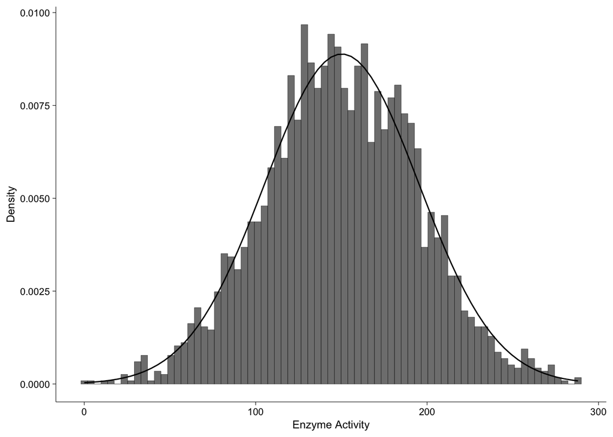

```r
activity_density_newer = tibble(activity = ggplot_build(p3)$data[[1]]$x, density = ggplot_build(p3)$data[[1]]$y)

fit_single_newer <- nlsLM(density ~ single_gauss(activity, C, mean, sigma), data = activity_density_newer, start=list(C=0.1, mean=150, sigma=0.2*150))

single_gauss_params_newer = as.list(summary(fit_single_newer)$param[,1])

single_gauss_preds_newer = do.call(single_gauss, c(list(x = activity_density_newer$activity), single_gauss_params_newer))

activity_density_newer$single_gauss_preds_newer = single_gauss_preds_newer

p3 + geom_line(data = activity_density_newer, aes(x = activity, y = single_gauss_preds_newer))
```

Then again with the double fit

```r
fit_double_newer <- nlsLM(density ~ double_gauss(activity, C1, mean1, sigma1, C2, mean2, sigma2), data = activity_density_newer, start=list(C1=0.075, mean1=145, sigma1=0.3*145, C2=0.075, mean2=155, sigma2=0.3*155))
```

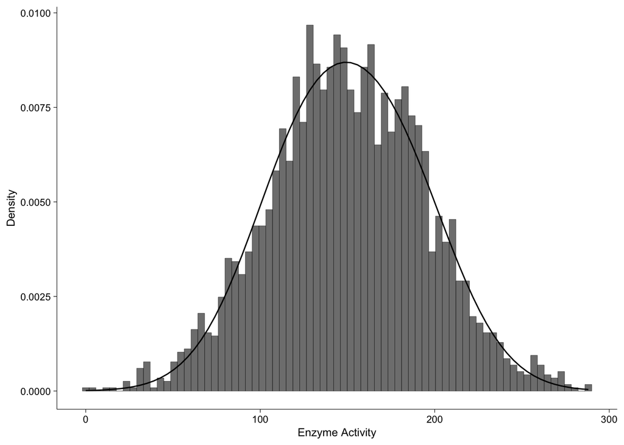

```r
double_gauss_params_newer = as.list(summary(fit_double_newer)$param[,1])

double_gauss_preds_newer = do.call(double_gauss, c(list(x = activity_density_newer$activity), double_gauss_params_newer))

activity_density$double_gauss_preds_newer = double_gauss_preds_newer

p3 + geom_line(data = activity_density_newer, aes(x = activity, y = double_gauss_preds_newer))
```

Fits are not as good… Let’s look at the AIC

```r
AIC(fit_single_newer, fit_double_newer)
```

```
##                  df       AIC
## fit_single_newer  4 -898.1721
## fit_double_newer  7 -894.5271
```

A few things to note about this analysis:

1. Assumptions on the simulated data may not be similar to the actual enzyme ones
2. Had to manually tweak starting parameters of Gaussian which is impractical for automated analysis
   - Come up with ways to extract estimates of height, mean, and sd

## Applying Shannon Index

We can use Dan’s suggestion of using some form of diversity index. In this case, the Shannon Index taken from biodiversity can be useful.

This works by looking at relative abundance (in our case could be density) of species and computes an index. It works like this:

```r
shannon = function(p) {
  return(-1*sum(p*log(p), na.rm = T))
}
```

Where p is the density across the length of p which is determined by bin size

Let’s try to apply it to the 3 graphs plotted above. I normalize the enzyme activity to the total, as this represents relative frequencies. We need something that adds up to 1 like a probability.

```r
shannon_indicies = c(shannon(activity_density$density / sum(activity_density$density)),
  shannon(activity_density_new$density / sum(activity_density_new$density)),
  shannon(activity_density_newer$density / sum(activity_density_newer$density)))

shannon_indicies
```

```
## [1] 3.983150 3.807854 3.843546
```

Diversity indicates are pretty similar… Let’s see if they graphically look alike

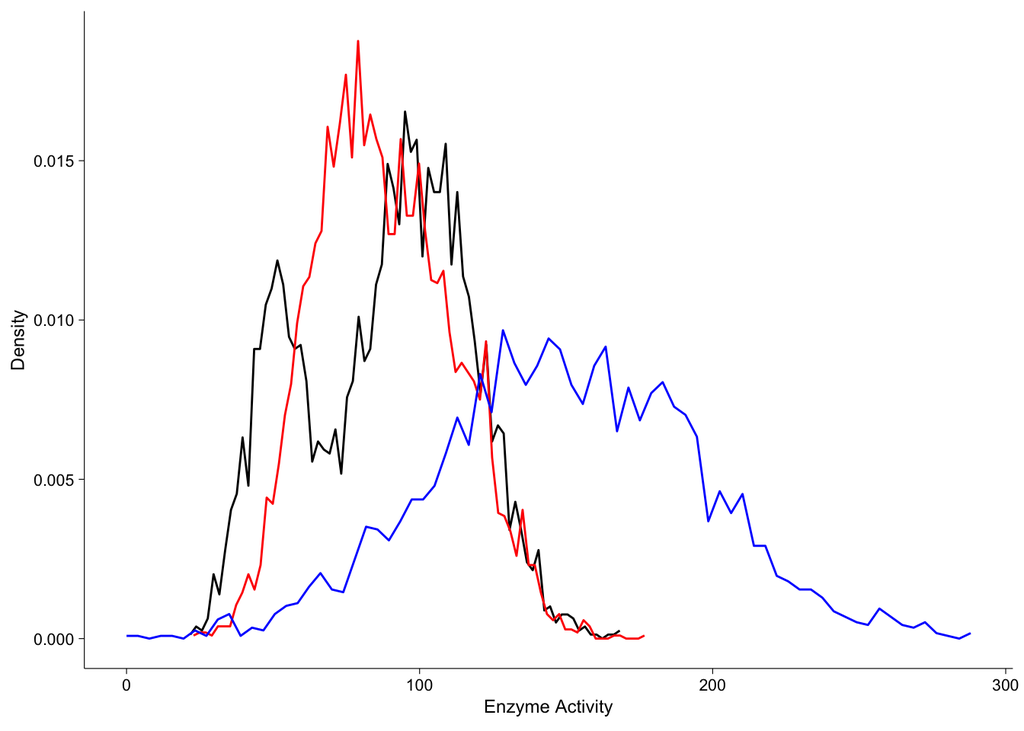

```r
activity_density %>%
  ggplot(aes(x = activity, y = density)) +
  geom_line() +
  geom_line(data = activity_density_new, aes(x = activity, y = density), color = "red") +
  geom_line(data = activity_density_newer, aes(x = activity, y = density), color = "blue") +
  labs(x = expression("Enzyme Activity"),
       y = "Density") +
  theme_classic() +
    theme(axis.line = element_line(size = 0.2, color = "black"), axis.ticks = element_line(size = 0.2, color = "black"), text = element_text(size = 9), axis.text = element_text(size = 8, color = "black"))
```

The two clear peaks appear to have a higher Shannon diversity index of 3.9831505, while the close peaks are 3.8078539 and finally the broad peak being 3.8435455